# Co-Testing Analysis: Combining Diagnostic Tests for Better Clinical Decision Making

ClinicoPath

2025-07-03

# 1 Introduction to Co-Testing Analysis

In clinical practice, physicians often use multiple diagnostic tests to improve diagnostic accuracy. The **co-testing analysis** function in ClinicoPath helps clinicians understand how combining two diagnostic tests affects post-test probabilities and clinical decision-making.

## 1.1 What is Co-Testing?

Co-testing refers to the simultaneous use of two diagnostic tests to improve diagnostic performance. This approach is common in:

- **Cancer screening** (e.g., mammography + ultrasound)
- **Infectious disease diagnosis** (e.g., antigen test + PCR)
- **Cardiac evaluation** (e.g., troponin + ECG)
- **Neurological assessment** (e.g., MRI + clinical examination)

## 1.2 Key Concepts

### 1.2.1 Post-Test Probability

The probability of disease after obtaining test results, calculated using Bayes’ theorem.

### 1.2.2 Test Independence

Whether the results of one test influence the results of another test, given the patient’s true disease status.

### 1.2.3 Likelihood Ratios

- **Positive Likelihood Ratio (PLR)**: How much more likely a positive result is in diseased vs. non-diseased patients
- **Negative Likelihood Ratio (NLR)**: How much more likely a negative result is in diseased vs. non-diseased patients

# 2 Understanding Test Independence vs. Dependence

## 2.1 Independent Tests

Tests are **conditionally independent** when the result of one test doesn’t affect the probability of the other test result, given the disease status.

**Mathematical formulation for independent tests:** - P(Test1+ and Test2+ | Disease+) = Sensitivity₁ × Sensitivity₂ - P(Test1+ and Test2+ | Disease-) = (1-Specificity₁) × (1-Specificity₂)

## 2.2 Dependent Tests

Tests are **conditionally dependent** when knowing one test result changes the probability of the other test result, even when disease status is known.

**When tests are likely dependent:** - Both tests measure similar biological phenomena - Tests use the same specimen or mechanism - Tests are affected by the same confounding factors

# 3 Clinical Examples

## 3.1 Example 1: COVID-19 Screening with Independent Tests

Let’s analyze a scenario where we use an antigen test and PCR test for COVID-19 screening, assuming they are independent.

```r
# COVID-19 screening with antigen + PCR (independent)
covid_independent <- cotest(
  test1_sens = 0.68,    # Antigen test sensitivity
  test1_spec = 0.99,    # Antigen test specificity
  test2_sens = 0.95,    # PCR test sensitivity
  test2_spec = 0.99,    # PCR test specificity
  prevalence = 0.05,    # Community prevalence (5%)
  indep = TRUE,         # Assume independence
  fagan = TRUE,         # Show Fagan nomogram
  fnote = TRUE          # Show explanatory footnotes
)
```

```
#> 1/1
#> 1/1
```

```r
print(covid_independent)
```

```
#>
#>  CO-TESTING ANALYSIS
#>
#>  Test Parameters
#>  ───────────────────────────────────────────────────────────────────────
#>    Test      Sensitivity    Specificity    Positive LR    Negative LR
#>  ───────────────────────────────────────────────────────────────────────
#>    Test 1     68.00000 ᵃ     99.00000 ᵇ     68.00000 ᵈ    0.32323232 ᵉ
#>    Test 2     95.00000       99.00000       95.00000      0.05050505
#>  ───────────────────────────────────────────────────────────────────────
#>    ᵃ Proportion of diseased patients correctly identified by Test 1
#>    ᵇ Proportion of non-diseased patients correctly identified by
#>    Test 1
#>    ᵈ Positive Likelihood Ratio: how much more likely a positive
#>    result is in diseased vs. non-diseased patients
#>    ᵉ Negative Likelihood Ratio: how much more likely a negative
#>    result is in diseased vs. non-diseased patients
#>
#>
#>  Co-Testing Results
#>  ──────────────────────────────────────────────────────────────────────────────────────────
#>    Scenario                Post-test Probability    Relative to Prevalence    Odds Ratio
#>  ──────────────────────────────────────────────────────────────────────────────────────────
#>    Test 1 Positive Only               78.16092               15.63218391         3.578947
#>    Test 2 Positive Only               83.33333               16.66666667         5.000000
#>    Both Tests Positive                99.70674 ᵃ             19.94134897 ᵇ     340.000000
#>    Both Tests Negative             8.584658e-4                0.01716932      8.592034e-4
#>  ──────────────────────────────────────────────────────────────────────────────────────────
#>    ᵃ Probability of disease after obtaining this test result combination
#>    ᵇ How many times more (or less) likely disease is after testing compared to before
#>    testing
#>
#>
#> character(0)
#>
#>  <div style="max-width: 800px;">
#>
#>  Understanding Test Dependence in Diagnostic Testing
#>
#>  What is conditional independence vs. dependence?
```

[output cut: 98 more lines]

```
#>  0.1%
#>  (0.02 times the pre-test probability).
#>
#>  When only one test is positive, the post-test probabilities are:
#>
#>  Test 1 positive only: 78.2%
#>  Test 2 positive only: 83.3%
#>
#> Prevalence: 0.05
#> Sensitivity: 0.9
#> Specificity: 0.8
#> Positive LR: 6460
#> Negative LR: 0.01632486
#> Post-test Probability (Positive test): 0.9970674
#> Post-test Probability (Negative test): 0.0008584658
```

[figure not shown]

### 3.1.1 Interpretation

- **Pre-test probability**: 5% (community prevalence)
- **Both tests positive**: Dramatically increases disease probability
- **Both tests negative**: Substantially decreases disease probability
- **Mixed results**: Individual test probabilities apply

## 3.2 Example 2: COVID-19 Screening with Dependent Tests

Now let’s consider the same tests but account for potential dependence (e.g., both tests may be affected by viral load).

```r
# COVID-19 screening with antigen + PCR (dependent)
covid_dependent <- cotest(
  test1_sens = 0.68,    # Antigen test sensitivity
  test1_spec = 0.99,    # Antigen test specificity
  test2_sens = 0.95,    # PCR test sensitivity
  test2_spec = 0.99,    # PCR test specificity
  prevalence = 0.05,    # Community prevalence (5%)
  indep = FALSE,        # Account for dependence
  cond_dep_pos = 0.15,  # Dependence in COVID+ patients
  cond_dep_neg = 0.05,  # Dependence in COVID- patients
  fagan = TRUE,         # Show Fagan nomogram
  fnote = TRUE          # Show explanatory footnotes
)
```

```
#> 1/1
#> 1/1
#> 1/1
```

```r
print(covid_dependent)
```

```
#>
#>  CO-TESTING ANALYSIS
#>
#>  Test Parameters
#>  ───────────────────────────────────────────────────────────────────────
#>    Test      Sensitivity    Specificity    Positive LR    Negative LR
#>  ───────────────────────────────────────────────────────────────────────
#>    Test 1     68.00000 ᵃ     99.00000 ᵇ     68.00000 ᵈ    0.32323232 ᵉ
#>    Test 2     95.00000       99.00000       95.00000      0.05050505
#>  ───────────────────────────────────────────────────────────────────────
#>    ᵃ Proportion of diseased patients correctly identified by Test 1
#>    ᵇ Proportion of non-diseased patients correctly identified by
#>    Test 1
#>    ᵈ Positive Likelihood Ratio: how much more likely a positive
#>    result is in diseased vs. non-diseased patients
#>    ᵉ Negative Likelihood Ratio: how much more likely a negative
#>    result is in diseased vs. non-diseased patients
#>
#>
#>  Co-Testing Results
#>  ───────────────────────────────────────────────────────────────────────────────────────────
#>    Scenario                Post-test Probability    Relative to Prevalence    Odds Ratio
#>  ───────────────────────────────────────────────────────────────────────────────────────────
#>    Test 1 Positive Only                9.49635                1.89927060       0.104927849
#>    Test 2 Positive Only               61.77198               12.35439598       1.615882268
#>    Both Tests Positive                98.31910 ᵃ             19.66381927 ᵇ    58.491810529
#>    Both Tests Negative                 0.16745                0.03348943       0.001677280
#>  ───────────────────────────────────────────────────────────────────────────────────────────
#>    ᵃ Probability of disease after obtaining this test result combination
#>    ᵇ How many times more (or less) likely disease is after testing compared to before
#>    testing
#>
#>
#>  Tests are modeled with conditional dependence:
#>
#>  Dependence for subjects with disease: 0.15
#>
#>  Dependence for subjects without disease: 0.05
#>
#>  Joint probabilities after accounting for dependence:
```

[output cut: 112 more lines]

```
#>  0.2%
#>  (0.03 times the pre-test probability).
#>
#>  When only one test is positive, the post-test probabilities are:
#>
#>  Test 1 positive only: 9.5%
#>  Test 2 positive only: 61.8%
#>
#> Prevalence: 0.05
#> Sensitivity: 0.9
#> Specificity: 0.8
#> Positive LR: 1111.344
#> Negative LR: 0.03186832
#> Post-test Probability (Positive test): 0.983191
#> Post-test Probability (Negative test): 0.001674472
```

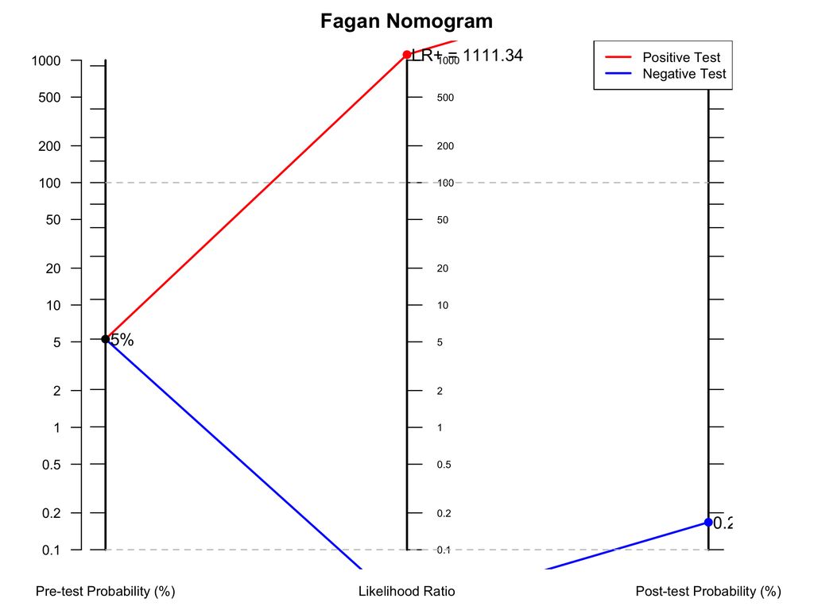

### 3.2.1 Key Differences

When accounting for dependence, the benefit of combined testing is typically **reduced** compared to the independence assumption. This is because: - Positive results are less surprising (tests tend to agree) - The tests provide less independent evidence

## 3.3 Example 3: Cancer Screening Scenario

Breast cancer screening using mammography and ultrasound in a high-risk population.

```r
# Breast cancer screening in high-risk women
cancer_screening <- cotest(
  test1_sens = 0.88,    # Mammography sensitivity
  test1_spec = 0.92,    # Mammography specificity
  test2_sens = 0.95,    # Ultrasound sensitivity
  test2_spec = 0.85,    # Ultrasound specificity
  prevalence = 0.08,    # High-risk population (8% prevalence)
  indep = FALSE,        # Tests likely dependent
  cond_dep_pos = 0.25,  # High dependence in cancer patients
  cond_dep_neg = 0.15,  # Moderate dependence in non-cancer patients
  fagan = TRUE,
  fnote = TRUE
)
```

```
#> 1/1
#> 1/1
#> 1/1
```

```r
print(cancer_screening)
```

```
#>
#>  CO-TESTING ANALYSIS
#>
#>  Test Parameters
#>  ───────────────────────────────────────────────────────────────────────
#>    Test      Sensitivity    Specificity    Positive LR    Negative LR
#>  ───────────────────────────────────────────────────────────────────────
#>    Test 1     88.00000 ᵃ     92.00000 ᵇ    11.000000 ᵈ    0.13043478 ᵉ
#>    Test 2     95.00000       85.00000       6.333333      0.05882353
#>  ───────────────────────────────────────────────────────────────────────
#>    ᵃ Proportion of diseased patients correctly identified by Test 1
#>    ᵇ Proportion of non-diseased patients correctly identified by
#>    Test 1
#>    ᵈ Positive Likelihood Ratio: how much more likely a positive
#>    result is in diseased vs. non-diseased patients
#>    ᵉ Negative Likelihood Ratio: how much more likely a negative
#>    result is in diseased vs. non-diseased patients
#>
#>
#>  Co-Testing Results
#>  ──────────────────────────────────────────────────────────────────────────────────────────
#>    Scenario                Post-test Probability    Relative to Prevalence    Odds Ratio
#>  ──────────────────────────────────────────────────────────────────────────────────────────
#>    Test 1 Positive Only                4.10081                0.51260170      0.042761714
#>    Test 2 Positive Only                6.35105                0.79388115      0.067817623
#>    Both Tests Positive                73.67101 ᵃ              9.20887639 ᵇ    2.798094962
#>    Both Tests Negative                 0.25813                0.03226593      0.002587955
#>  ──────────────────────────────────────────────────────────────────────────────────────────
#>    ᵃ Probability of disease after obtaining this test result combination
#>    ᵇ How many times more (or less) likely disease is after testing compared to before
#>    testing
#>
#>
#>  Tests are modeled with conditional dependence:
#>
#>  Dependence for subjects with disease: 0.25
#>
#>  Dependence for subjects without disease: 0.15
#>
#>  Joint probabilities after accounting for dependence:
```

[output cut: 112 more lines]

```
#>  0.3%
#>  (0.03 times the pre-test probability).
#>
#>  When only one test is positive, the post-test probabilities are:
#>
#>  Test 1 positive only: 4.1%
#>  Test 2 positive only: 6.4%
#>
#> Prevalence: 0.08
#> Sensitivity: 0.9
#> Specificity: 0.8
#> Positive LR: 32.17809
#> Negative LR: 0.02976148
#> Post-test Probability (Positive test): 0.7367101
#> Post-test Probability (Negative test): 0.002581275
```

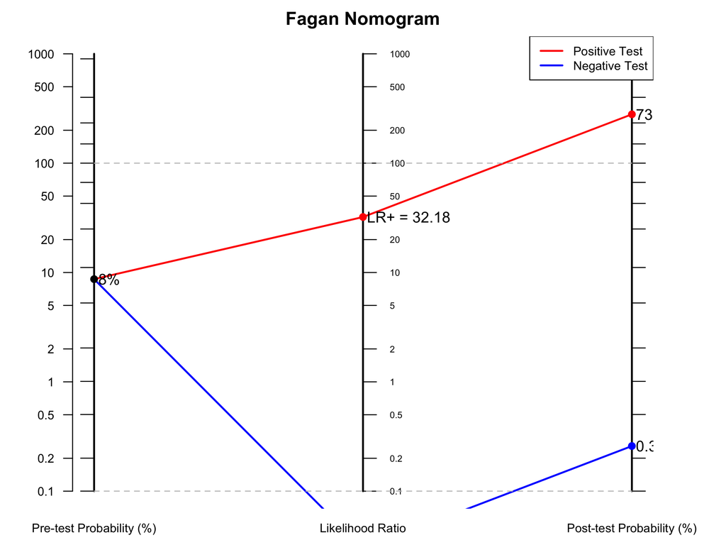

### 3.3.1 Clinical Decision Points

This analysis helps determine: - **When to biopsy**: High post-test probability after positive tests - **When to reassure**: Very low probability after negative tests - **When to use additional testing**: Intermediate probabilities

## 3.4 Example 4: Cardiac Biomarkers in Emergency Department

Evaluating chest pain patients using troponin and CK-MB.

```r
# Cardiac biomarkers for myocardial infarction
cardiac_biomarkers <- cotest(
  test1_sens = 0.92,    # Troponin sensitivity
  test1_spec = 0.89,    # Troponin specificity
  test2_sens = 0.85,    # CK-MB sensitivity
  test2_spec = 0.94,    # CK-MB specificity
  prevalence = 0.25,    # ED chest pain patients (25% MI rate)
  indep = FALSE,        # Biomarkers likely correlated
  cond_dep_pos = 0.30,  # High correlation in MI patients
  cond_dep_neg = 0.20,  # Moderate correlation in non-MI patients
  fagan = TRUE,
  fnote = TRUE
)
```

```
#> 1/1
#> 1/1
#> 1/1
```

```r
print(cardiac_biomarkers)
```

```
#>
#>  CO-TESTING ANALYSIS
#>
#>  Test Parameters
#>  ───────────────────────────────────────────────────────────────────────
#>    Test      Sensitivity    Specificity    Positive LR    Negative LR
#>  ───────────────────────────────────────────────────────────────────────
#>    Test 1     92.00000 ᵃ     89.00000 ᵇ     8.363636 ᵈ    0.08988764 ᵉ
#>    Test 2     85.00000       94.00000      14.166667      0.15957447
#>  ───────────────────────────────────────────────────────────────────────
#>    ᵃ Proportion of diseased patients correctly identified by Test 1
#>    ᵇ Proportion of non-diseased patients correctly identified by
#>    Test 1
#>    ᵈ Positive Likelihood Ratio: how much more likely a positive
#>    result is in diseased vs. non-diseased patients
#>    ᵉ Negative Likelihood Ratio: how much more likely a negative
#>    result is in diseased vs. non-diseased patients
#>
#>
#>  Co-Testing Results
#>  ──────────────────────────────────────────────────────────────────────────────────────────
#>    Scenario                Post-test Probability    Relative to Prevalence    Odds Ratio
#>  ──────────────────────────────────────────────────────────────────────────────────────────
#>    Test 1 Positive Only               29.08488                1.16339518       0.41013650
#>    Test 2 Positive Only               25.19417                1.00776670       0.33679416
#>    Both Tests Positive                92.64554 ᵃ              3.70582150 ᵇ    12.59718691
#>    Both Tests Negative                 1.58205                0.06328210       0.01607484
#>  ──────────────────────────────────────────────────────────────────────────────────────────
#>    ᵃ Probability of disease after obtaining this test result combination
#>    ᵇ How many times more (or less) likely disease is after testing compared to before
#>    testing
#>
#>
#>  Tests are modeled with conditional dependence:
#>
#>  Dependence for subjects with disease: 0.30
#>
#>  Dependence for subjects without disease: 0.20
#>
#>  Joint probabilities after accounting for dependence:
```

[output cut: 112 more lines]

```
#>  1.6%
#>  (0.06 times the pre-test probability).
#>
#>  When only one test is positive, the post-test probabilities are:
#>
#>  Test 1 positive only: 29.1%
#>  Test 2 positive only: 25.2%
#>
#> Prevalence: 0.25
#> Sensitivity: 0.9
#> Specificity: 0.8
#> Positive LR: 37.79156
#> Negative LR: 0.04822451
#> Post-test Probability (Positive test): 0.9264554
#> Post-test Probability (Negative test): 0.01582053
```

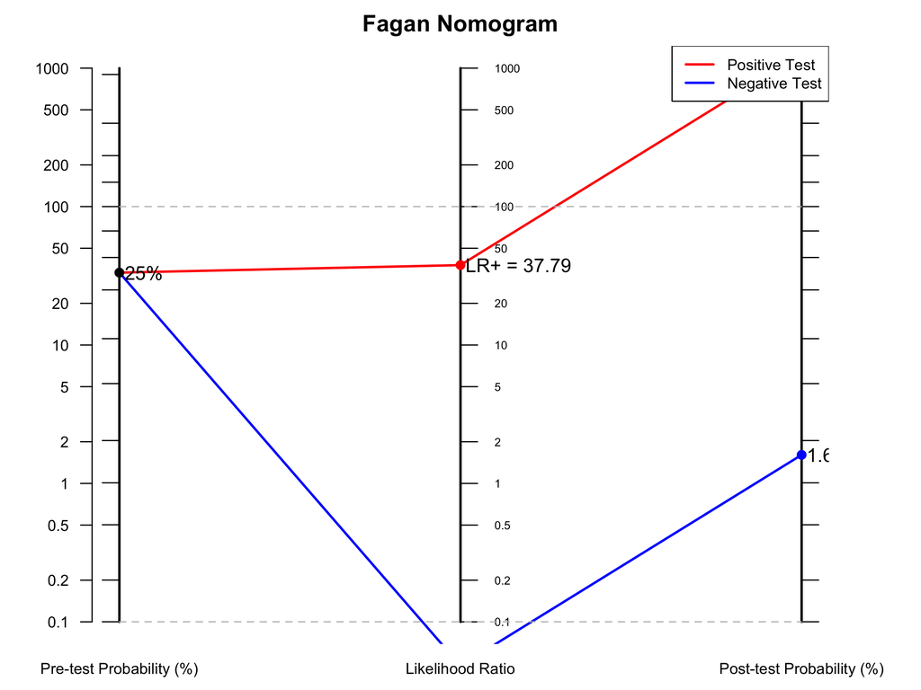

### 3.4.1 Clinical Application

- **Both positive**: Strong evidence for MI, immediate intervention
- **Both negative**: Low MI probability, consider discharge protocols
- **Discordant results**: May need additional testing or clinical correlation

# 4 Practical Guidelines for Co-Testing Analysis

## 4.1 When to Use Independent vs. Dependent Models

### 4.1.1 Use **Independent Model** when:

- Tests measure completely different biological phenomena
- Tests use different specimens or mechanisms
- No evidence of correlation between test results
- Limited information about test interactions

### 4.1.2 Use **Dependent Model** when:

- Tests measure similar biological phenomena
- Tests use the same specimen
- Previous studies show correlation
- Both tests affected by same confounding factors

## 4.2 Estimating Dependence Parameters

When dependence parameters are unknown:

1. **Literature Review**: Look for studies with paired testing data
2. **Expert Opinion**: Consult specialists familiar with the tests
3. **Sensitivity Analysis**: Test range of plausible values (0.05, 0.1, 0.2, 0.3)
4. **Conservative Approach**: Use moderate dependence (0.1-0.2) when uncertain

```r
# Sensitivity analysis with different dependence levels
scenarios <- list(
  "Low Dependence" = 0.05,
  "Moderate Dependence" = 0.15,
  "High Dependence" = 0.30
)

sensitivity_results <- lapply(names(scenarios), function(scenario_name) {
  dep_value <- scenarios[[scenario_name]]

  result <- cotest(
    test1_sens = 0.85,
    test1_spec = 0.90,
    test2_sens = 0.80,
    test2_spec = 0.95,
    prevalence = 0.10,
    indep = FALSE,
    cond_dep_pos = dep_value,
    cond_dep_neg = dep_value
  )

  cat("\n", scenario_name, "(ρ =", dep_value, "):\n")
  print(result)

  return(result)
})
```

```
#> 1/1
#> 1/1
#> 1/1
#>
#>  Low Dependence (ρ = 0.05 ):
#>
#>  CO-TESTING ANALYSIS
#>
#>  Test Parameters
#>  ──────────────────────────────────────────────────────────────────────
#>    Test      Sensitivity    Specificity    Positive LR    Negative LR
#>  ──────────────────────────────────────────────────────────────────────
#>    Test 1       85.00000       90.00000       8.500000      0.1666667
#>    Test 2       80.00000       95.00000      16.000000      0.2105263
#>  ──────────────────────────────────────────────────────────────────────
#>
#>
#>  Co-Testing Results
#>  ──────────────────────────────────────────────────────────────────────────────────────────
#>    Scenario                Post-test Probability    Relative to Prevalence    Odds Ratio
#>  ──────────────────────────────────────────────────────────────────────────────────────────
#>    Test 1 Positive Only                 16.47639                1.64763901    0.197266259
#>    Test 2 Positive Only                 23.10611                2.31061123    0.300493485
#>    Both Tests Positive                  90.22767                9.02276672    9.232971236
#>    Both Tests Negative                   0.47853                0.04785302    0.004808311
#>  ──────────────────────────────────────────────────────────────────────────────────────────
#>
#>
#>  Tests are modeled with conditional dependence:
#>
#>  Dependence for subjects with disease: 0.05
#>
#>  Dependence for subjects without disease: 0.05
#>
#>  Joint probabilities after accounting for dependence:
#>
#>  P(Test1+,Test2+ | Disease+): 0.6871
#>
#>  P(Test1+,Test2+ | Disease-): 0.0083
#>
```

[output cut: 409 more lines]

```
#>  The disease prevalence (pre-test probability) in this population is
#>  10.0%.
#>
#>  If both tests are positive, the probability of disease increases to
#>  76.5%
#>  (7.7 times the pre-test probability).
#>
#>  If both tests are negative, the probability of disease decreases to
#>  0.9%
#>  (0.09 times the pre-test probability).
#>
#>  When only one test is positive, the post-test probabilities are:
#>
#>  Test 1 positive only: 15.8%
#>  Test 2 positive only: 25.2%
```

## 4.3 Impact of Ignoring Dependence

Ignoring conditional dependence when it exists typically leads to:

- **Overestimating** the benefit of combined testing
- **Exaggerating** post-test probabilities
- **Overly optimistic** assessment of diagnostic accuracy
- **Unrealistic** confidence intervals

# 5 Advanced Applications

## 5.1 Sequential vs. Simultaneous Testing

While this function models simultaneous testing, it can inform sequential testing strategies:

```r
# First test: High sensitivity screening test
first_test <- cotest(
  test1_sens = 0.95,    # High sensitivity screening
  test1_spec = 0.80,    # Lower specificity acceptable
  test2_sens = 0.95,    # Dummy second test (same values)
  test2_spec = 0.80,
  prevalence = 0.05,
  indep = TRUE
)
```

```
#> 1/1
#> 1/1
```

```r
# If first test positive, use confirmatory test
confirmatory_test <- cotest(
  test1_sens = 0.95,    # Original screening test
  test1_spec = 0.80,
  test2_sens = 0.85,    # Confirmatory test (different characteristics)
  test2_spec = 0.98,    # Higher specificity
  prevalence = 0.25,    # Higher prevalence after positive screen
  indep = FALSE,
  cond_dep_pos = 0.20,
  cond_dep_neg = 0.10
)
```

```
#> 1/1
#> 1/1
#> 1/1
```

```r
cat("Sequential Testing Strategy:\n")
```

```
#> Sequential Testing Strategy:
```

```r
cat("Step 1 - Screening Test Results:\n")
```

```
#> Step 1 - Screening Test Results:
```

```r
print(first_test)
```

```
#>
#>  CO-TESTING ANALYSIS
#>
#>  Test Parameters
#>  ──────────────────────────────────────────────────────────────────────
#>    Test      Sensitivity    Specificity    Positive LR    Negative LR
#>  ──────────────────────────────────────────────────────────────────────
#>    Test 1       95.00000       80.00000       4.750000     0.06250000
#>    Test 2       95.00000       80.00000       4.750000     0.06250000
#>  ──────────────────────────────────────────────────────────────────────
#>
#>
#>  Co-Testing Results
#>  ──────────────────────────────────────────────────────────────────────────────────────────
#>    Scenario                Post-test Probability    Relative to Prevalence    Odds Ratio
#>  ──────────────────────────────────────────────────────────────────────────────────────────
#>    Test 1 Positive Only                 20.00000               4.000000000      0.2500000
#>    Test 2 Positive Only                 20.00000               4.000000000      0.2500000
#>    Both Tests Positive                  54.28571              10.857142857      1.1875000
#>    Both Tests Negative               2.055498e-4               0.004110997    2.055921e-4
#>  ──────────────────────────────────────────────────────────────────────────────────────────
#>
#>
#> character(0)
#>
#>  <div style="max-width: 800px;">
#>
#>  Understanding Test Dependence in Diagnostic Testing
#>
#>  What is conditional independence vs. dependence?
#>
#>  Two diagnostic tests are conditionally independent if the result of
#>  one test does not influence the result of the other test, *given the
#>  disease status*. In other words, within the diseased population, the
#>  probability of Test 1 being positive is not affected by knowing the
#>  result of Test 2, and vice versa. The same applies within the
#>  non-diseased population.
#>
#>  Tests are conditionally dependent when the result of one test affects
#>  the probability of the other test result, even when we know the
```

[output cut: 80 more lines]

```
#>  The disease prevalence (pre-test probability) in this population is
#>  5.0%.
#>
#>  If both tests are positive, the probability of disease increases to
#>  54.3%
#>  (10.9 times the pre-test probability).
#>
#>  If both tests are negative, the probability of disease decreases to
#>  0.0%
#>  (0.00 times the pre-test probability).
#>
#>  When only one test is positive, the post-test probabilities are:
#>
#>  Test 1 positive only: 20.0%
#>  Test 2 positive only: 20.0%
```

```r
cat("\nStep 2 - Confirmatory Testing (if screen positive):\n")
```

```
#>
#> Step 2 - Confirmatory Testing (if screen positive):
```

```r
print(confirmatory_test)
```

```
#>
#>  CO-TESTING ANALYSIS
#>
#>  Test Parameters
#>  ──────────────────────────────────────────────────────────────────────
#>    Test      Sensitivity    Specificity    Positive LR    Negative LR
#>  ──────────────────────────────────────────────────────────────────────
#>    Test 1       95.00000       80.00000       4.750000     0.06250000
#>    Test 2       85.00000       98.00000      42.500000     0.15306122
#>  ──────────────────────────────────────────────────────────────────────
#>
#>
#>  Co-Testing Results
#>  ───────────────────────────────────────────────────────────────────────────────────────────
#>    Scenario                Post-test Probability    Relative to Prevalence    Odds Ratio
#>  ───────────────────────────────────────────────────────────────────────────────────────────
#>    Test 1 Positive Only                 18.18209                0.72728344     0.222226221
#>    Test 2 Positive Only                 46.33238                1.85329536     0.863321076
#>    Both Tests Positive                  96.61918                3.86476721    28.578624389
#>    Both Tests Negative                   0.96428                0.03857139     0.009736737
#>  ───────────────────────────────────────────────────────────────────────────────────────────
#>
#>
#>  Tests are modeled with conditional dependence:
#>
#>  Dependence for subjects with disease: 0.20
#>
#>  Dependence for subjects without disease: 0.10
#>
#>  Joint probabilities after accounting for dependence:
#>
#>  P(Test1+,Test2+ | Disease+): 0.8231
#>
#>  P(Test1+,Test2+ | Disease-): 0.0096
#>
#>  P(Test1-,Test2- | Disease+): 0.0231
#>
#>  P(Test1-,Test2- | Disease-): 0.7896
#>
#>  <div style="max-width: 800px;">
```

[output cut: 94 more lines]

```
#>  The disease prevalence (pre-test probability) in this population is
#>  25.0%.
#>
#>  If both tests are positive, the probability of disease increases to
#>  96.6%
#>  (3.9 times the pre-test probability).
#>
#>  If both tests are negative, the probability of disease decreases to
#>  1.0%
#>  (0.04 times the pre-test probability).
#>
#>  When only one test is positive, the post-test probabilities are:
#>
#>  Test 1 positive only: 18.2%
#>  Test 2 positive only: 46.3%
```

## 5.2 Cost-Effectiveness Considerations

Co-testing analysis can inform cost-effectiveness decisions:

```r
# High-cost, high-accuracy test combination
high_cost_scenario <- cotest(
  test1_sens = 0.98,    # Expensive, highly accurate test 1
  test1_spec = 0.99,
  test2_sens = 0.96,    # Expensive, highly accurate test 2
  test2_spec = 0.99,
  prevalence = 0.02,    # Low prevalence setting
  indep = TRUE,
  fagan = TRUE
)
```

```
#> 1/1
#> 1/1
```

```r
# Moderate-cost, good-accuracy test combination
moderate_cost_scenario <- cotest(
  test1_sens = 0.85,    # Moderate cost, good accuracy test 1
  test1_spec = 0.90,
  test2_sens = 0.88,    # Moderate cost, good accuracy test 2
  test2_spec = 0.92,
  prevalence = 0.02,    # Same prevalence
  indep = TRUE,
  fagan = TRUE
)
```

```
#> 1/1
#> 1/1
```

```r
cat("High-Cost Scenario:\n")
```

```
#> High-Cost Scenario:
```

```r
print(high_cost_scenario)
```

```
#>
#>  CO-TESTING ANALYSIS
#>
#>  Test Parameters
#>  ──────────────────────────────────────────────────────────────────────
#>    Test      Sensitivity    Specificity    Positive LR    Negative LR
#>  ──────────────────────────────────────────────────────────────────────
#>    Test 1       98.00000       99.00000       98.00000     0.02020202
#>    Test 2       96.00000       99.00000       96.00000     0.04040404
#>  ──────────────────────────────────────────────────────────────────────
#>
#>
#>  Co-Testing Results
#>  ──────────────────────────────────────────────────────────────────────────────────────────
#>    Scenario                Post-test Probability    Relative to Prevalence    Odds Ratio
#>  ──────────────────────────────────────────────────────────────────────────────────────────
#>    Test 1 Positive Only                 66.66667                  33.33333       2.000000
#>    Test 2 Positive Only                 66.20690                  33.10345       1.959184
#>    Both Tests Positive                  99.48187                  49.74093     192.000000
#>    Both Tests Negative               1.665775e-5               8.328874e-4    1.665803e-5
#>  ──────────────────────────────────────────────────────────────────────────────────────────
#>
#>
#> character(0)
#>
#>  <div style="max-width: 800px;">
#>
#>  Understanding Test Dependence in Diagnostic Testing
#>
#>  What is conditional independence vs. dependence?
#>
#>  Two diagnostic tests are conditionally independent if the result of
#>  one test does not influence the result of the other test, *given the
#>  disease status*. In other words, within the diseased population, the
#>  probability of Test 1 being positive is not affected by knowing the
#>  result of Test 2, and vice versa. The same applies within the
#>  non-diseased population.
#>
#>  Tests are conditionally dependent when the result of one test affects
#>  the probability of the other test result, even when we know the
```

[output cut: 88 more lines]

```
#>  0.0%
#>  (0.00 times the pre-test probability).
#>
#>  When only one test is positive, the post-test probabilities are:
#>
#>  Test 1 positive only: 66.7%
#>  Test 2 positive only: 66.2%
#>
#> Prevalence: 0.02
#> Sensitivity: 0.9
#> Specificity: 0.8
#> Positive LR: 9408
#> Negative LR: 0.0008162432
#> Post-test Probability (Positive test): 0.9948187
#> Post-test Probability (Negative test): 1.665775e-05
```

[figure not shown]

```
#> NULL

cat("\nModerate-Cost Scenario:\n")
#>
#> Moderate-Cost Scenario:
print(moderate_cost_scenario)
#>
#>  CO-TESTING ANALYSIS
#>
#>  Test Parameters
#>  ──────────────────────────────────────────────────────────────────────
#>    Test      Sensitivity    Specificity    Positive LR    Negative LR
#>  ──────────────────────────────────────────────────────────────────────
#>    Test 1       85.00000       90.00000       8.500000      0.1666667
#>    Test 2       88.00000       92.00000      11.000000      0.1304348
#>  ──────────────────────────────────────────────────────────────────────
#>
#>
#>  Co-Testing Results
#>  ──────────────────────────────────────────────────────────────────────────────────────────
#>    Scenario                Post-test Probability    Relative to Prevalence    Odds Ratio
#>  ──────────────────────────────────────────────────────────────────────────────────────────
#>    Test 1 Positive Only                 14.78261                7.39130435      0.1734694
#>    Test 2 Positive Only                 18.33333                9.16666667      0.2244898
#>    Both Tests Positive                  65.61404               32.80701754      1.9081633
#>    Both Tests Negative               4.434590e-4                0.02217295    4.436557e-4
#>  ──────────────────────────────────────────────────────────────────────────────────────────
#>
#>
#> character(0)
#>
#>  <div style="max-width: 800px;">
#>
#>  Understanding Test Dependence in Diagnostic Testing
#>
#>  What is conditional independence vs. dependence?
#>
#>  Two diagnostic tests are conditionally independent if the result of
#>  one test does not influence the result of the other test, *given the
#>  disease status*. In other words, within the diseased population, the
```

[output cut: 94 more lines]

```
#>  0.0%
#>  (0.02 times the pre-test probability).
#>
#>  When only one test is positive, the post-test probabilities are:
#>
#>  Test 1 positive only: 14.8%
#>  Test 2 positive only: 18.3%
#>
#> Prevalence: 0.02
#> Sensitivity: 0.9
#> Specificity: 0.8
#> Positive LR: 93.5
#> Negative LR: 0.02173913
#> Post-test Probability (Positive test): 0.6561404
#> Post-test Probability (Negative test): 0.000443459
```

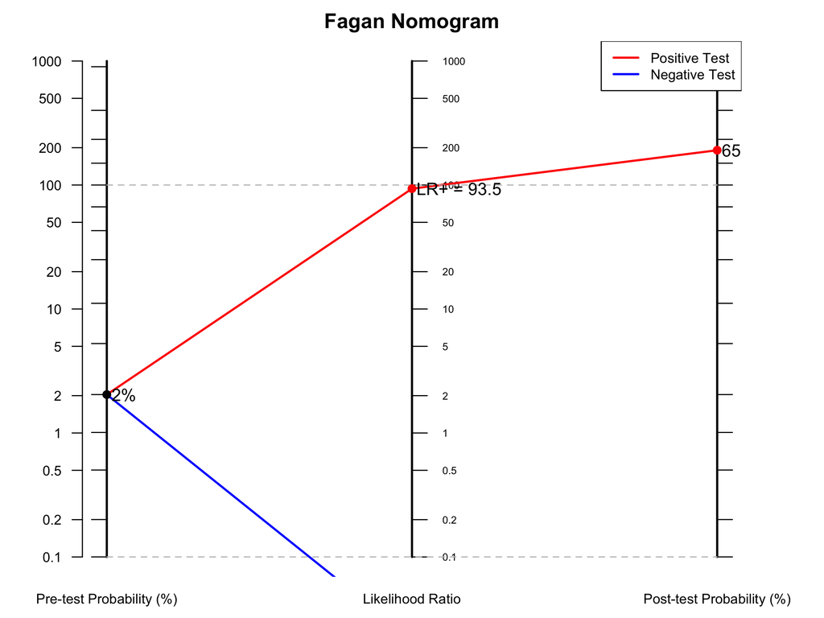

# 6 Clinical Decision Thresholds

Understanding when co-testing changes clinical decisions:

## 6.1 Treatment Threshold Analysis

```r
# Define clinical scenarios with different action thresholds
scenarios <- data.frame(
  Clinical_Setting = c("Screening", "Symptomatic", "High_Risk"),
  Prevalence = c(0.01, 0.15, 0.40),
  Treatment_Threshold = c(0.05, 0.20, 0.60),
  Test_Threshold = c(0.02, 0.08, 0.30)
)

for (i in 1:nrow(scenarios)) {
  setting <- scenarios[i, ]

  cat("\n", setting$Clinical_Setting, "Setting:\n")
  cat("Prevalence:", setting$Prevalence * 100, "%\n")
  cat("Treatment threshold:", setting$Treatment_Threshold * 100, "%\n")

  result <- cotest(
    test1_sens = 0.85,
    test1_spec = 0.90,
    test2_sens = 0.80,
    test2_spec = 0.95,
    prevalence = setting$Prevalence,
    indep = TRUE
  )

  print(result)
}
```

```
#>
#>  Screening Setting:
#> Prevalence: 1 %
#> Treatment threshold: 5 %
#> 1/1
#> 1/1
#>
#>  CO-TESTING ANALYSIS
#>
#>  Test Parameters
#>  ──────────────────────────────────────────────────────────────────────
#>    Test      Sensitivity    Specificity    Positive LR    Negative LR
#>  ──────────────────────────────────────────────────────────────────────
#>    Test 1       85.00000       90.00000       8.500000      0.1666667
#>    Test 2       80.00000       95.00000      16.000000      0.2105263
#>  ──────────────────────────────────────────────────────────────────────
#>
#>
#>  Co-Testing Results
#>  ──────────────────────────────────────────────────────────────────────────────────────────
#>    Scenario                Post-test Probability    Relative to Prevalence    Odds Ratio
#>  ──────────────────────────────────────────────────────────────────────────────────────────
#>    Test 1 Positive Only                  7.90698                7.90697674     0.08585859
#>    Test 2 Positive Only                 13.91304               13.91304348     0.16161616
#>    Both Tests Positive                  57.87234               57.87234043     1.37373737
#>    Both Tests Negative               3.542958e-4                0.03542958    3.544214e-4
#>  ──────────────────────────────────────────────────────────────────────────────────────────
#>
#>
#> character(0)
#>
#>  <div style="max-width: 800px;">
#>
#>  Understanding Test Dependence in Diagnostic Testing
#>
#>  What is conditional independence vs. dependence?
#>
#>  Two diagnostic tests are conditionally independent if the result of
#>  one test does not influence the result of the other test, *given the
#>  disease status*. In other words, within the diseased population, the
```

[output cut: 370 more lines]

```
#>  The disease prevalence (pre-test probability) in this population is
#>  40.0%.
#>
#>  If both tests are positive, the probability of disease increases to
#>  98.9%
#>  (2.5 times the pre-test probability).
#>
#>  If both tests are negative, the probability of disease decreases to
#>  2.3%
#>  (0.06 times the pre-test probability).
#>
#>  When only one test is positive, the post-test probabilities are:
#>
#>  Test 1 positive only: 85.0%
#>  Test 2 positive only: 91.4%
```

# 7 Summary and Best Practices

## 7.1 Key Takeaways

1. **Co-testing can significantly improve diagnostic accuracy** when used appropriately
2. **Test dependence matters** - ignoring it can lead to overoptimistic results
3. **Clinical context is crucial** - consider prevalence, thresholds, and consequences
4. **Sensitivity analysis** helps understand uncertainty in dependence parameters

## 7.2 Best Practices

### 7.2.1 Before Analysis

- Understand the biological basis for potential test dependence
- Gather accurate sensitivity and specificity data
- Estimate realistic prevalence for your population
- Define clinical decision thresholds

### 7.2.2 During Analysis

- Start with independence assumption as baseline
- Test dependence scenarios based on biological plausibility
- Use sensitivity analysis for uncertain parameters
- Consider both positive and negative test combinations

### 7.2.3 After Analysis

- Interpret results in clinical context
- Consider cost-effectiveness implications
- Validate findings with clinical experience
- Update analysis as new data becomes available

## 7.3 Limitations

- Assumes binary test results (positive/negative)
- Requires known test characteristics
- Dependence parameters may be difficult to estimate
- Does not account for test timing or sequence effects

## 7.4 Conclusion

Co-testing analysis provides a quantitative framework for understanding how multiple diagnostic tests interact to influence clinical decision-making. By properly accounting for test dependence and clinical context, this analysis can guide more informed use of diagnostic testing in clinical practice.

The `cotest` function in ClinicoPath makes these complex calculations accessible to clinicians, providing both numerical results and visual tools (Fagan nomograms) to support evidence-based medical decision-making.

*This vignette demonstrates the use of the `cotest` function for analyzing combined diagnostic tests. For more information about ClinicoPath, visit our documentation or contact the development team.*